# Theme comparison

Corey Runkel

10/25/2021

## Sean and Corey don’t like ggplot’s defaults

We make a lot of plots in our research, and aim to make even more in the future. So, it’s important that we like what we make. Sean doesn’t like a number of small things that `ggplot` insists using, such as the grey background. Further, a coherent style can add polish and professionalism to our publications. Corey doesn’t like the ubiquity of the defaults.

## Package functions to make our theme easy to use

We have some disagreements on how our theme should look. But we agree that we need one that is easy to use, or we—and especially others who are not as familiar with `ggplot` and **R**—won’t use it. This all means that we need to put together a theme of our own, something that a user can call at the end of the `ggplot` chain. It could also be helpful to suggest some color palettes that fulfill a few requirements, namely accessibility.

## We shouldn’t write our own theme from scratch

Luckily, we can build on what professional designers before us have done. And we can be confident in a theme designed professionally by limiting our search to themes that are:

1. Robust: support the widest set of `ggplot` functions and normally used plugins (such as `scales`)
2. Scaled appropriately: our figures top out around 615 pixels in width

To test these goals, themes will need to render large datasets in our three core geometries—areas, columns, and points—with two text annotations at a size of $615px \cdot 400px$

## Tests

The contenders will come from three libraries (`lubridate` just handles dates):

```r
library(tidyverse)
library(lubridate)
```

```r
library(bbplot)
library(ggthemes)
fredr::fredr_set_key(readRDS("../../bbel/US GFC/fred_key.Rds"))
```

First, to import the area plot, from my TAF case:

```r
series <-  c("Treasuries" = "WSHOTSL",
            "Securities lent" = "WSDEALL",
            "Repos" = "WORAL",
            "Other assets" = "WOFRAL",
            "Float" = "WOFSRBFL",
            "Swaps" = "WACBS",
            "TAF" = "RESPPALTNWW",
            "Broker-dealer" = "H0RESPPALDDNWW",
            "Primary credit" = "WLCFLPCL",
            "Secondary credit" = "WLCFLSCL",
            "Seasonal credit" = "WLCFLSECL",
            "Maiden Lane 1" = "WAML1L",
            "Maiden Lane 2" = "WAML2L",
            "Maiden Lane 3" = "WAML3L",
            "ABCP" = "H0RESPPALDFNWW",
            "CP portfolio" = "WACPFFL",
            "AIG" = "H0RESPPALDGNWW",
            "MBS" = "WSHOMCB",
            "FADS" = "WSHOFDSL",
            "TALF" = "WLCFTALFL")

h41 <- purrr::map_dfr(series, fredr::fredr, observation_start = as_date("2007-06-01"), observation_end = as_date("2010-06-01"), .id = "H.4.1") %>%
      filter(H.4.1 != "Float") %>%
#PLOT STARTS HERE#
      ggplot() +
      geom_area(aes(date, value, fill = H.4.1)) +
      dutchmasters::scale_fill_dutchmasters() +
      scale_x_date(date_breaks = "3 months", date_labels = "%b %y") +
      scale_y_continuous(labels = scales::dollar_format()) +
      labs(x = "Week", y = "Outstanding assets (millions)", fill = NULL, caption = "Source: H.4.1 Release")
```

Next, the scatterplot from my BAPF case:

```r
bapf <- valet::get_group("BAPF_TRANSACTION_DATA") %>%
  mutate(issuer_name = fct_recode(issuer_name,
                                  "BMO" = "Bank of Montreal",
                                  "BNS" = "Bank of Nova Scotia",
                                  "BNP Paribas" = "BNP Paribas Canada",
                                  "CIBC" = "Canadian Imperial Bank of Commerce",
                                  "Desjardins" = "Federation des caisses Desjardins du Quebec",
                                  "HSBC" = "HSBC Bank Canada",
                                  "Laurentian" = "Laurentian Bank of Canada",
                                  "NBC" = "National Bank of Canada",
                                  "RBC" = "Royal Bank of Canada",
                                  "TD" = "The Toronto Dominion Bank")) %>%
#PLOT STARTS HERE#
    ggplot(aes(settlement_date)) +
  geom_point(aes(y = purchase_yield, col = issuer_name, size = amount_purchased/1000000000), position = position_jitter(width = 1), alpha = .5) +
  geom_step(aes(y = reserve_rate), data = filter(mutate(valet::get_group("BANKERS_ACCEPTANCE_PURCHASE_FACILITY"), across(amount_purchased:amount_to_be_purchased, ~ .x*1000000)), settlement_date <= as_date("2020-06-01")), linetype = 3) +
  scale_x_date(date_labels = "%B %d") +
  scale_y_continuous(labels = scales::percent_format(scale = 1)) +
  scale_size_continuous(labels = scales::dollar_format(prefix = "C$", suffix = " billion", accuracy = 1)) +
  labs(x = "Auction date", y = "Yield of purchased BAs", col = "Issuer", size = "Amount")
```

Last, the column plot from my ECS case:

```r
ecs <- unzip(zipfile = "../../bbel/EU GFC/data/tops.zip", files = "output/newstaging/tops.csv") %>% #unzip file downloaded from link above
  read_csv(guess_max = 2500) %>%
  rename_with(~ str_remove(.x, "t_"), t_class:t_is_canceled) %>% #remove t_ leading each variable
  select(class:ref, procedure, allot_dt, settlement_dt:auction_type, intended_volume, marginal_rate, allotment_at_marginal_rate, alloted_amount, weighted_average_rate, bid_amount, number_of_bidders, min_rate_bids, max_rate_bids) %>% #remove irrelevant columns
  mutate_at(vars(class, procedure, auction_type), as_factor) %>% #change three character variables to factors
  mutate(term = fct_relevel(case_when(class == "LTRO" & duration < 81 ~ "STRO",
                          class == "LTRO" & duration %in% 82:110 ~ "3 month",
                          class == "LTRO" & duration %in% 170:190 ~ "6 month",
                          class == "LTRO" & duration %in% 190:400 ~ "1 year"), "1 year", "STRO", "6 month", "3 month")) %>%
  filter(!is.na(settlement_dt)) %>% #remove OMOs that never settled
      filter(class == "LTRO", between(settlement_dt, as_date("2007-08-24"), as_date("2010-04-01"))) %>%
      mutate(outstanding = if_else(alloted_amount > bid_amount, bid_amount, alloted_amount), date = settlement_dt) %>%
      select(ref, settlement_dt, maturity_dt, date, outstanding, term, marginal_rate) %>%
      group_by(ref, term, settlement_dt, maturity_dt, marginal_rate) %>%
      complete(date = seq.Date(date, maturity_dt-1, by = "day")) %>%
      fill(outstanding) %>%
      ungroup() %>%
#PLOT STARTS HERE#
  ggplot() +
  geom_rect(aes(xmin = as_date("2008-10-15"), xmax = as_date("2010-12-31"), ymin = -Inf, ymax = Inf), fill = "#4a4a4a", alpha = .002) +
  geom_col(aes(date, outstanding/1000, fill = term), alpha = .5) +
  scale_y_continuous(labels = scales::dollar_format(prefix = "€")) +
  scale_x_date(date_labels = "%b %Y") +
  scale_fill_manual(values = wesanderson::wes_palette("Chevalier1", n = 4, type = "discrete")) +
  labs(x = NULL, y = "Outstanding SLTROs (billions)")
```

First, let’s test the default `ggplot` themes: ### Default

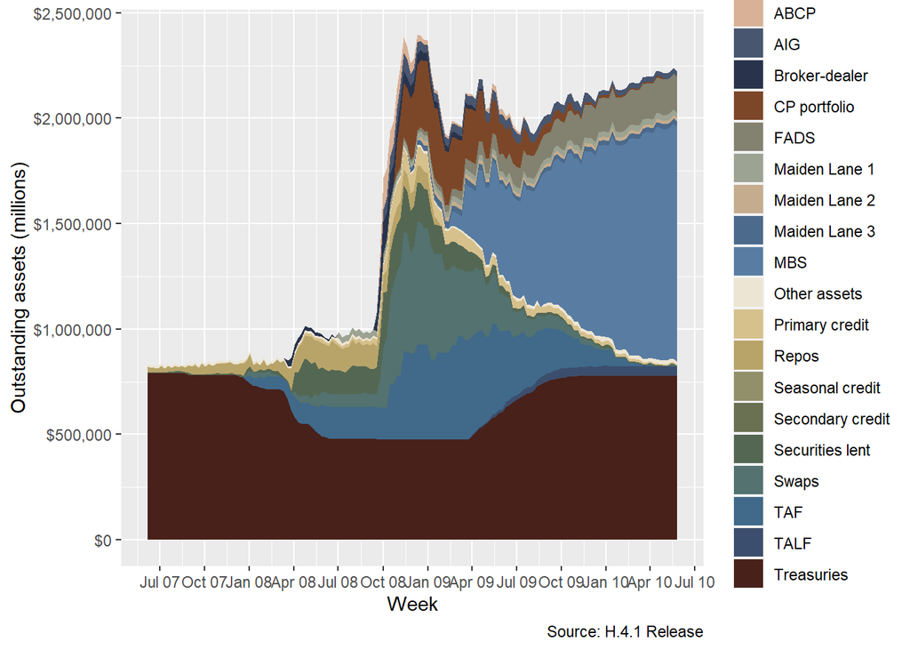

```r
h41
```

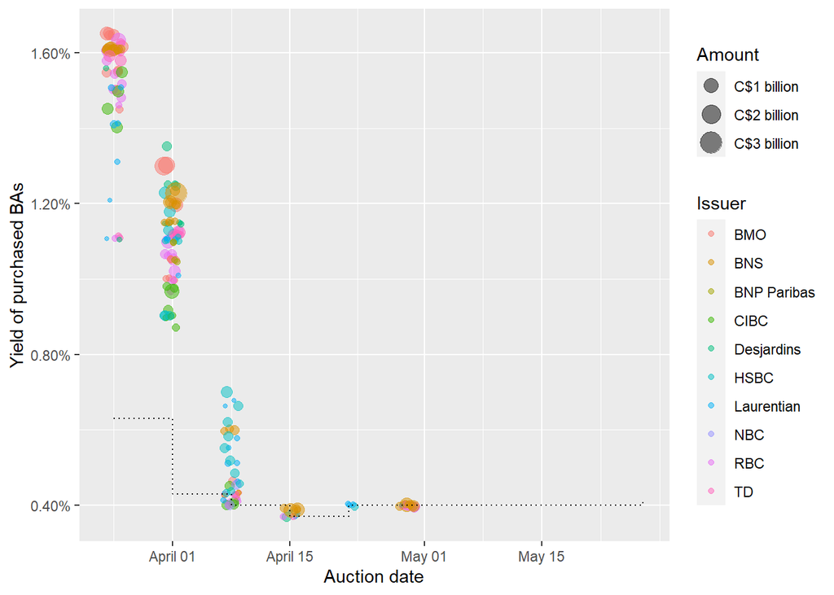

```r
bapf
```

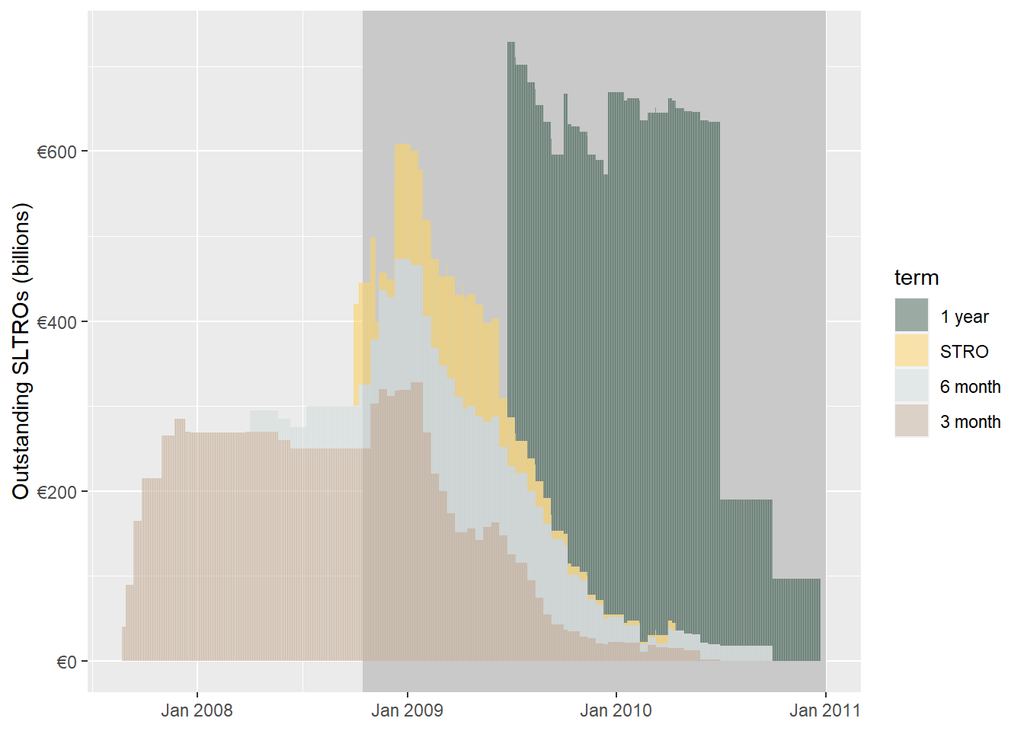

```r
ecs
```

### theme_bw

[output not shown]

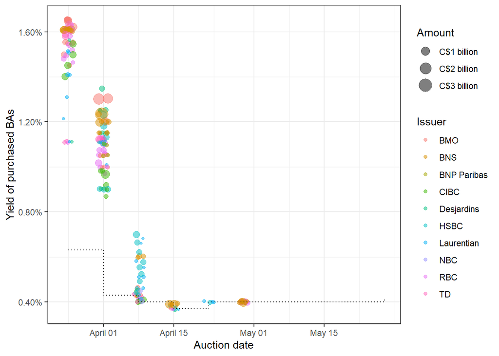

```r
bapf + theme_bw()
```

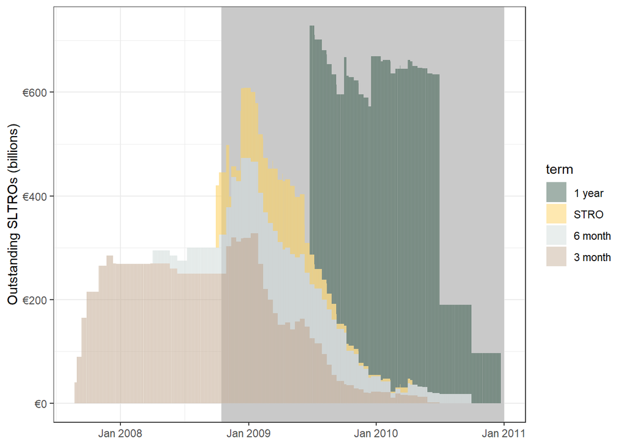

```r
ecs + theme_bw()
```

### theme_minimal

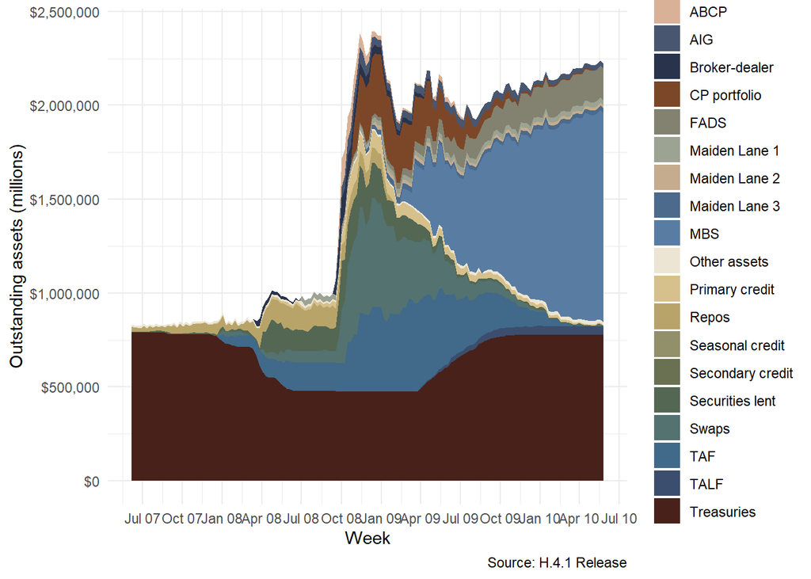

```r
h41 + theme_minimal()
```

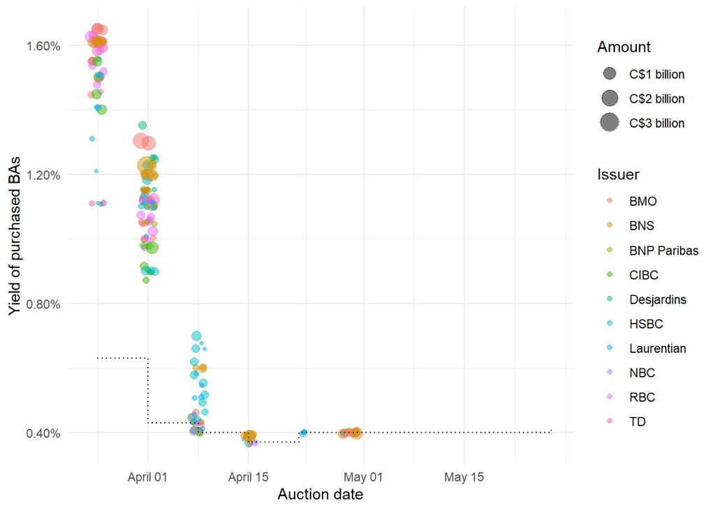

```r
bapf + theme_minimal()
```

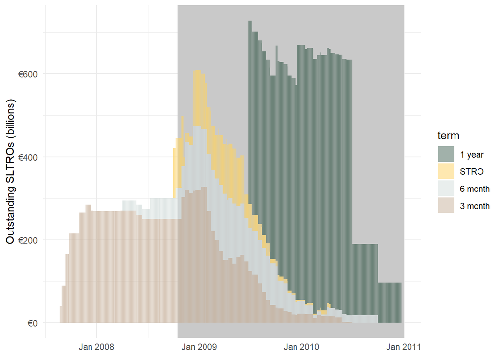

```r
ecs + theme_minimal()
```

### theme_classic

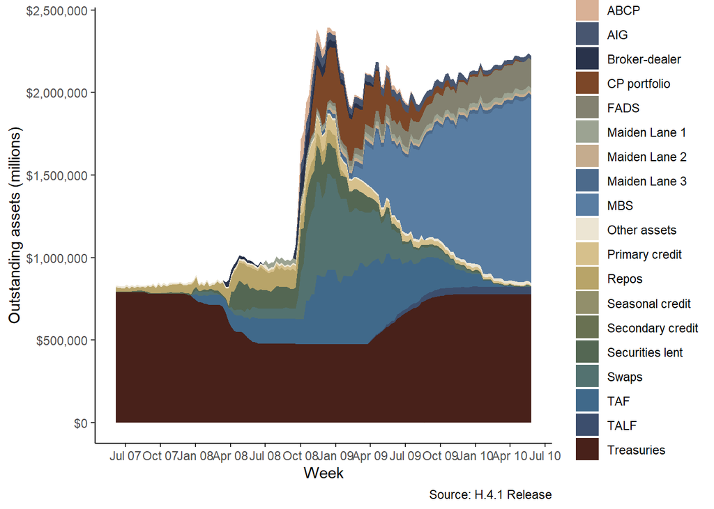

```r
h41 + theme_classic()
```

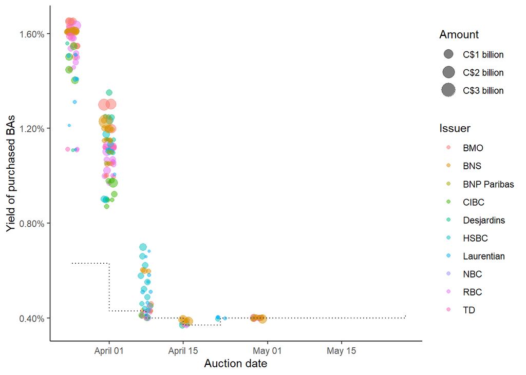

```r
bapf + theme_classic()
```

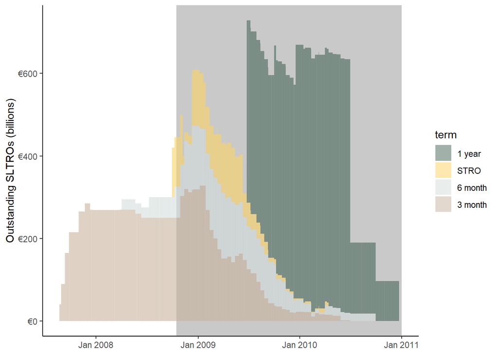

```r
ecs + theme_classic()
```

Next, let’s try the BBC’s theme: ### bbplot

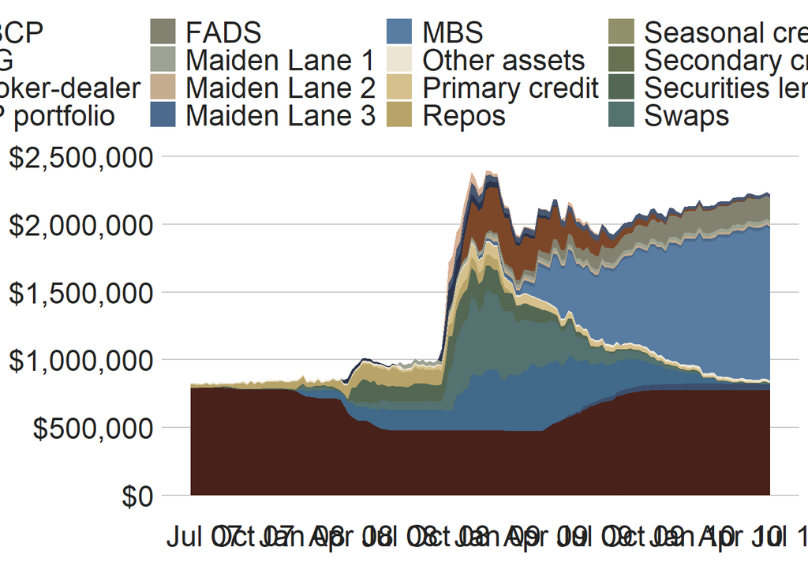

```r
h41 + bbc_style()
```

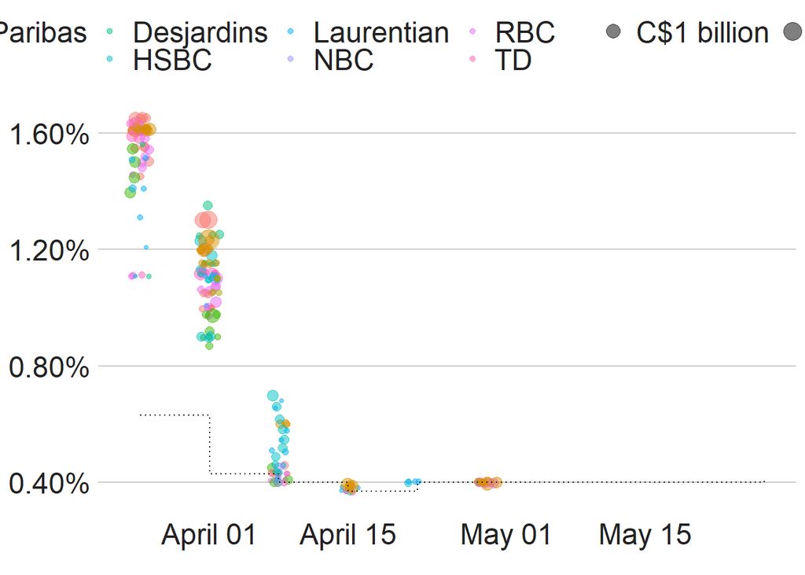

```r
bapf + bbc_style()
```

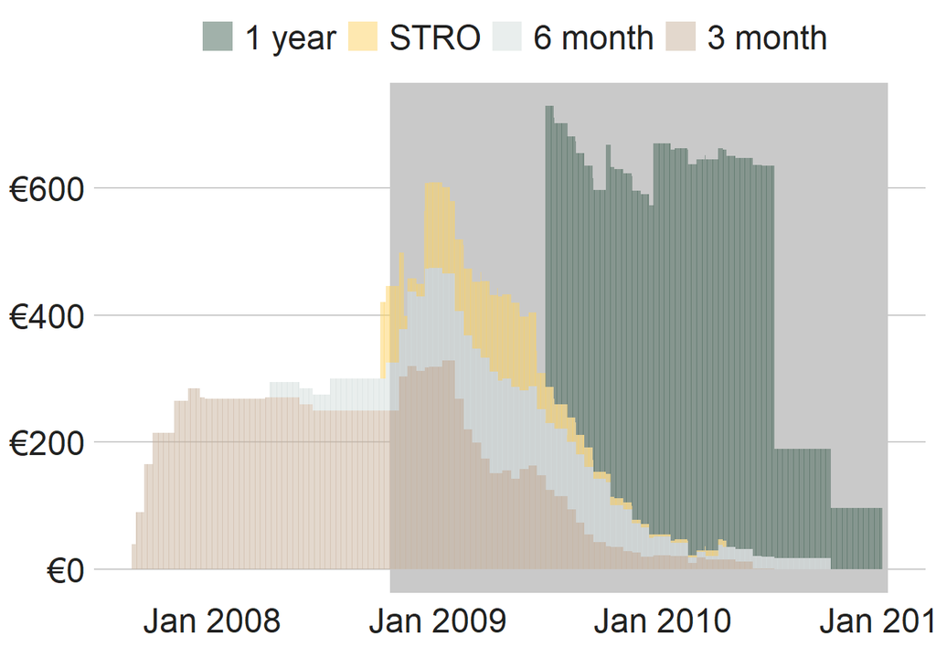

```r
ecs + bbc_style()
```

Then, some ggthemes: ### theme_few

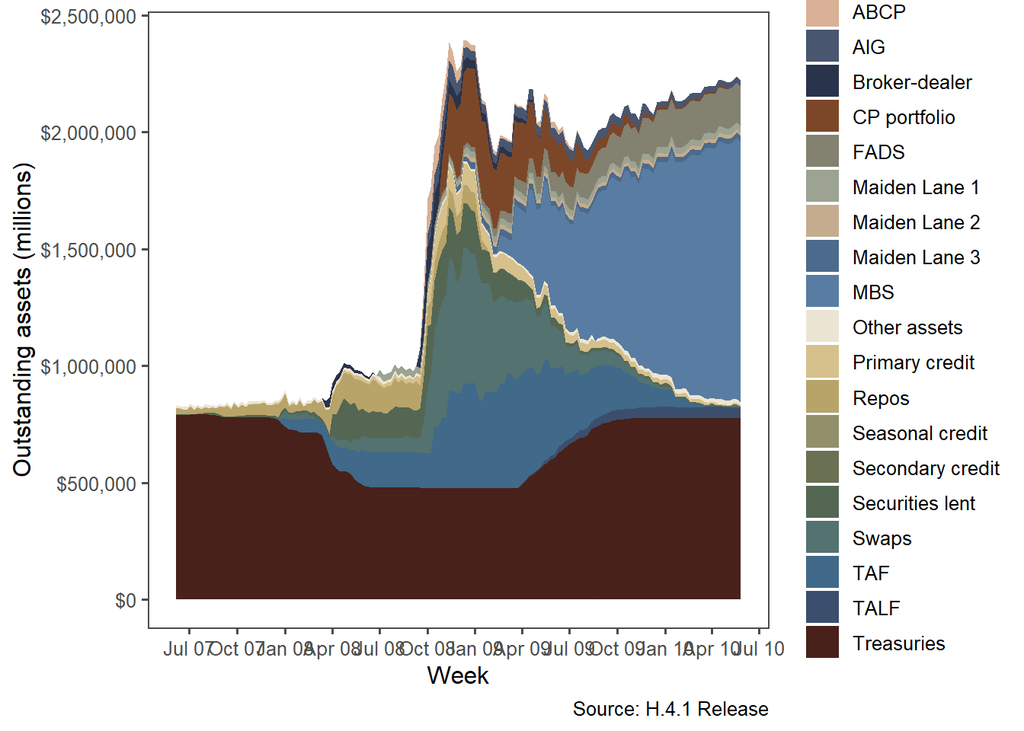

```r
h41 + theme_few()
```

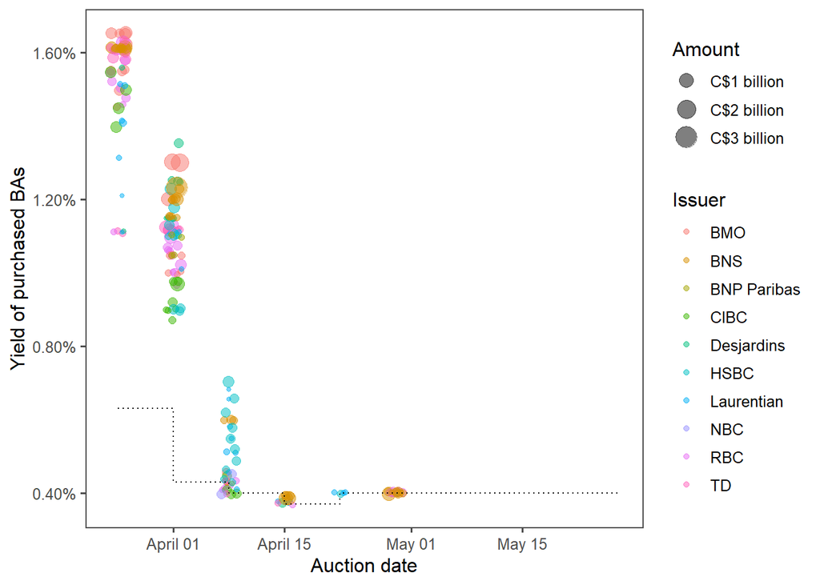

```r
bapf + theme_few()
```

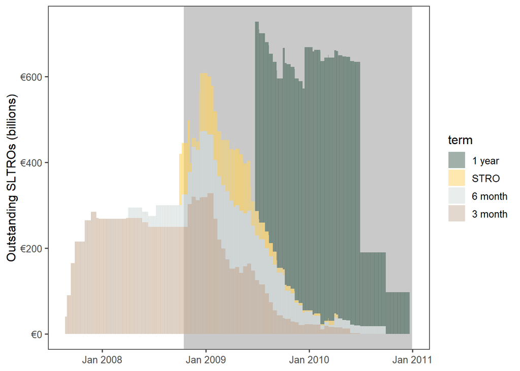

```r
ecs + theme_few()
```

### theme_gdocs

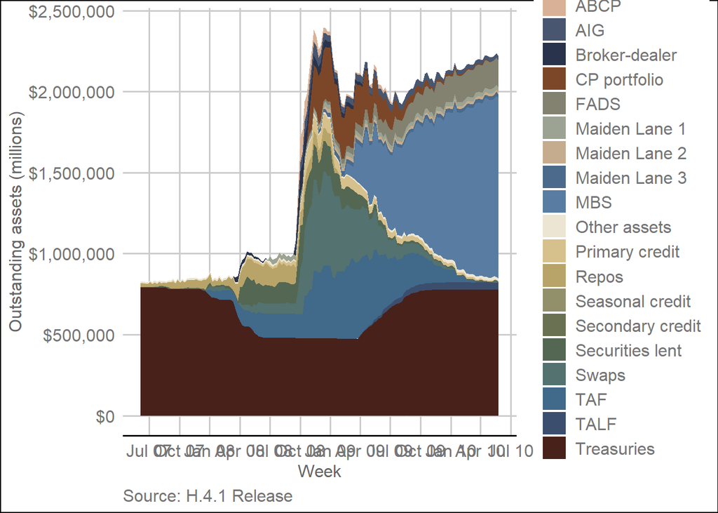

```r
h41 + theme_gdocs()
```

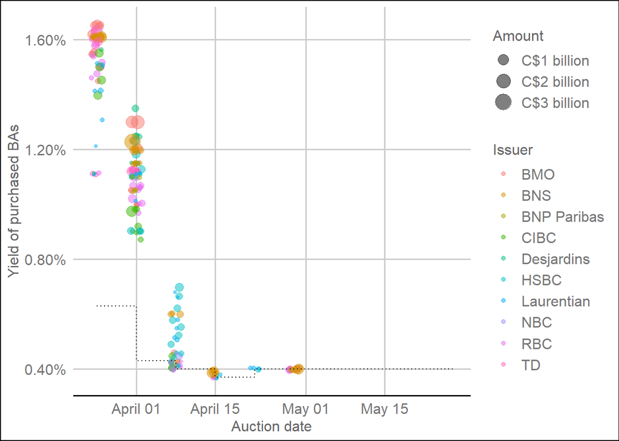

```r
bapf + theme_gdocs()
```

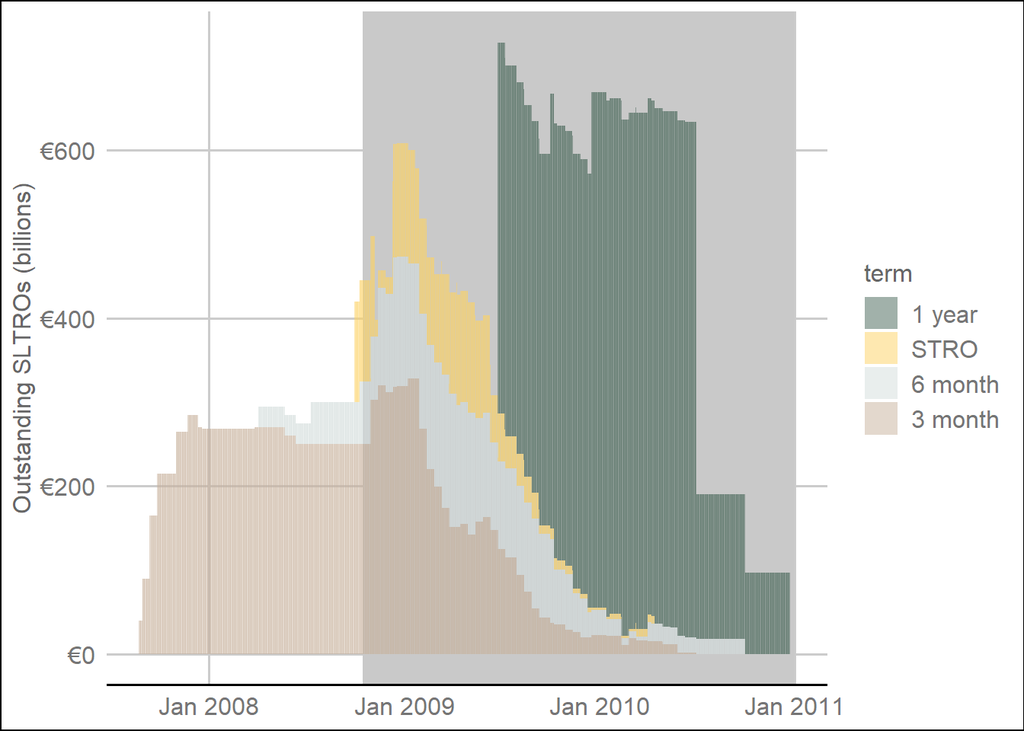

```r
ecs + theme_gdocs()
```

### theme_tufte

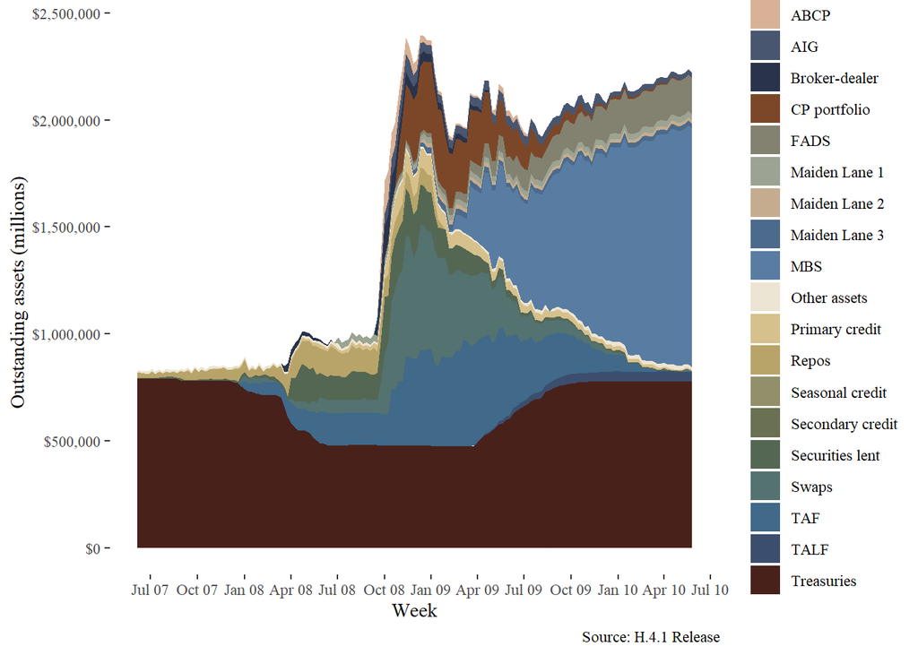

```r
h41 + theme_tufte()
```

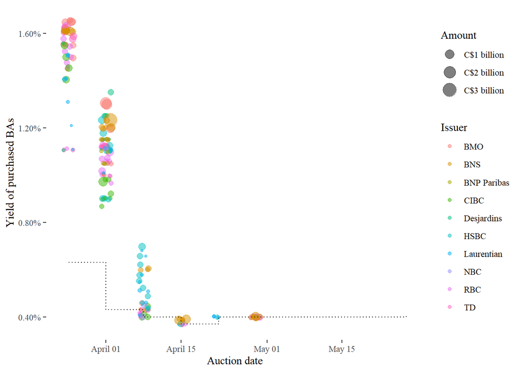

```r
bapf + theme_tufte()
```

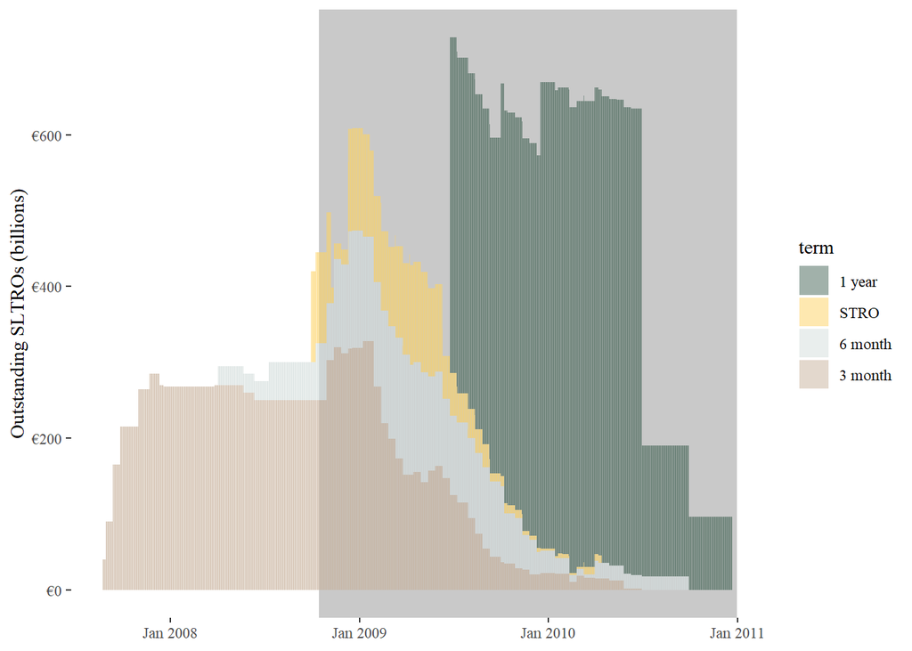

```r
ecs + theme_tufte()
```